# Projekt Tuatara Challenge

Konrad Więcko

### Temat projektu

Predykcja kwoty odszkodowania na podstawie danych udostępnionych przez firmę Allstate w serwisie kaggle.com

https://www.kaggle.com/c/allstate-claims-severity

### Plan prezentacji

- Założenia projektowe
- Schemat wykorzystanej infrastruktury obliczeniowej
- Wstępne manipulacje danymi
- Pierwsza próba uczenia maszynowego
- Poprawa predykcji
- Podsumowanie projektu

### Założenia projektowe

- Wykorzystanie Apache Flume'a do ładowania danych do Apache Hadoop'a
- Wykorzystanie Apache Spark'a do prostych manipulacji danymi oraz uczenia maszynowego (MLlib)
- Wykorzystanie R jako:
  - interfejsu do obsługi HDFS'a oraz SPARK'a (sparklyr)
  - narzędzia do bardziej złożonych manipulacji danymi
- Weryfikacja/Optymalizacja modeli stworzonych w Apache Spark'u
- Napisanie pakietu ułatwiającego pracę z danymi w R: https://github.com/KWiecko/tuataraChallenge

### Schemat wykorzystanej infrastruktury obliczeniowej

- Klaster obliczeniowy (zarówno dla Hadoop'a jak i Spark'a) składał się się z 4 wirtualnych maszyn (narzędziem służącym do wirtualizacji był VirtualBox)

[figure not shown]

[figure not shown]

### Schemat wykorzystanej infrastruktury obliczeniowej

Schemat przetwarzania danych:

- Dane za pomocą Apache Flume'a były ładowane do HDFS
- Dane poprzez RStudio (sparklyr) były odczytywane z HDFS, ładowane do Apache Spark'a, a następnie do pamięci w celu wykonania określonych manipulacji
- Dane po manipulacjach były ładowane do Apache Spark'a aby przeprowadzić na nich uczenie maszynowe
- W celu weryfikacji dane były powtórnie ładowane do RStudio

### Schemat wykorzystanej infrastruktury obliczeniowej

[figure not shown]

### Wstępne manipulacje danymi

Ogólna charakterystyka danych:

Wartość odszkodowania miała rozkład log-normalny. Z tego względu zdecydowano się na przygotowanie dwóch przypadków zbioru danych:

1. Zmienna `loss` pozostawiona bez zmian (`loss` osnaczało wysokość odszkodowania)
2. Zmienna `loss` została zlogatyrmowana loss' = ln(`loss`)

### Wstępne manipulacje danymi

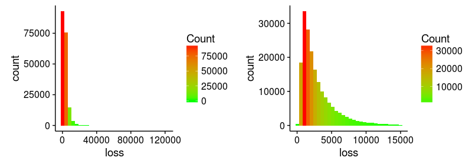

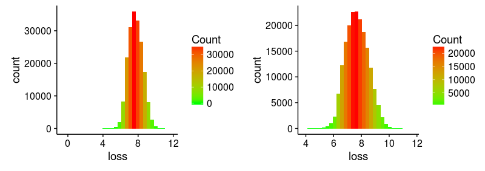

### Wstępne manipulacje danymi

Ogólna charakterystyka danych c.d.:

Zmienne przeważnie nie mały rozkładów normalnych

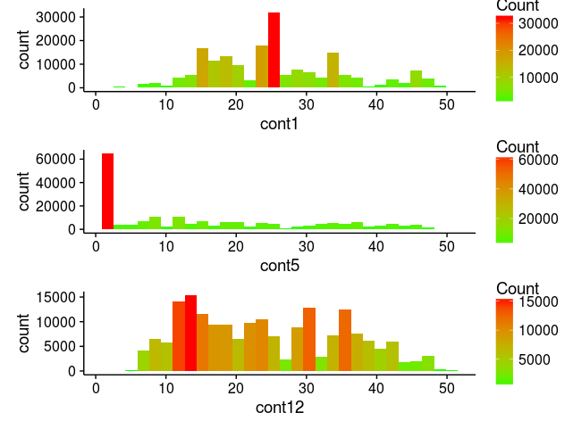

### Wstępne manipulacje danymi

Ogólna charakterystyka danych c.d.

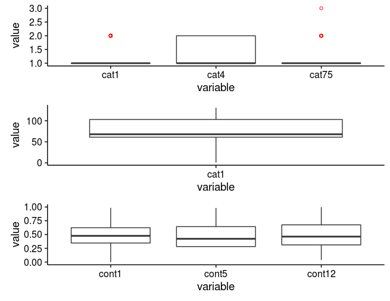

### Wstępne manipulacje danymi

Zmienne często były ze sobą mocno skorelowane

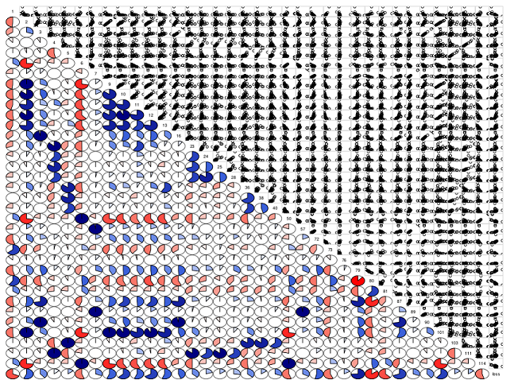

### Wstępne manipulacje danymi

Po zapoznaniu się z danymi zaproponowana została następująca faktoryzacja zbioru danych:

- przypadek 1. mapowanie liter na cyfry/liczby indywidualnie - w skryptach oznaczane jako 'case1'

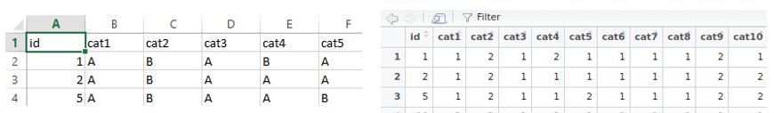

- przypadek 2. mapowanie liter na cyfry/liczby globalnie - w skryptach oznaczane jako 'case2'

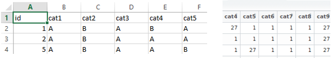

### Uczenie maszynowe

Algorytmy wykorzystane do uczenia maszynowego:

- ml_generalized_linear_regression
- ml_gradient_boosted_trees

Wszystkie modele były porównywane ze sobą przy wykorzystaniu:

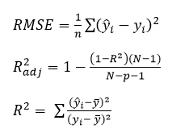

Ponadto modele liniowe porównywane były ze sobą za pomocą kryterium informacyjnego Akaikego (AIC)

### Poprawa predykcji

Pierwsza iteracja uczenia maszynowego - RMSE ~= 2500

W celu poprawienia predykcji modeli:

- Ze zbioru wszystkich zmiennych zostały wybrane takie, których korelacja ze zmienną `loss` była istotna statystycznie
- Ze zbioru wszystkich zmiennych zostały wybrane takie, których korelacja ze zmienną `loss` była co najmniej słaba (współczynnik korelacji >= 0.1)
  - Ze zbioru wszystkich zmiennych skorelowanych co najmniej słabo ze zmienną `loss` zostały wybrane takie, których wzajemna korelacja nie przekraczała 0.15
  - Ze zbioru treningowego zostały usunięte obserwacje odstające (pozostawiono jedynie obserwacje mieszczące się w przedziale +- 2 odchylenia standardowe od średniej ln(`loss`))
  - modele XGB miały zadawaną różną głębokość drzewa

### Poprawa predykcji

Pierwszy etap uczenia maszynowego został wykonany za pomocą biblioteki MLlib zgodnie ze schematem:

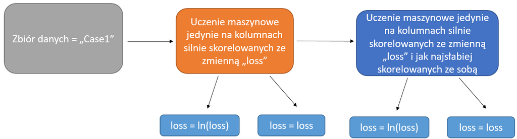

### Poprawa predykcji

Wykresy R<sup>2</sup> dla różnych modeli liniowych oraz zbiorów treningowych i testowych:

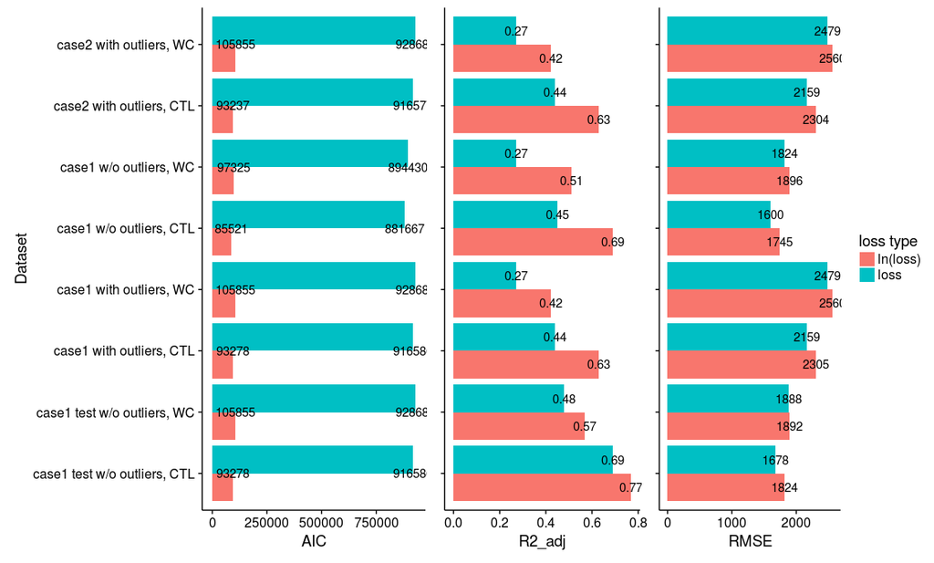

### Poprawa predykcji

Wpływ głębokości drzewa oraz zestawu danych na RMSE

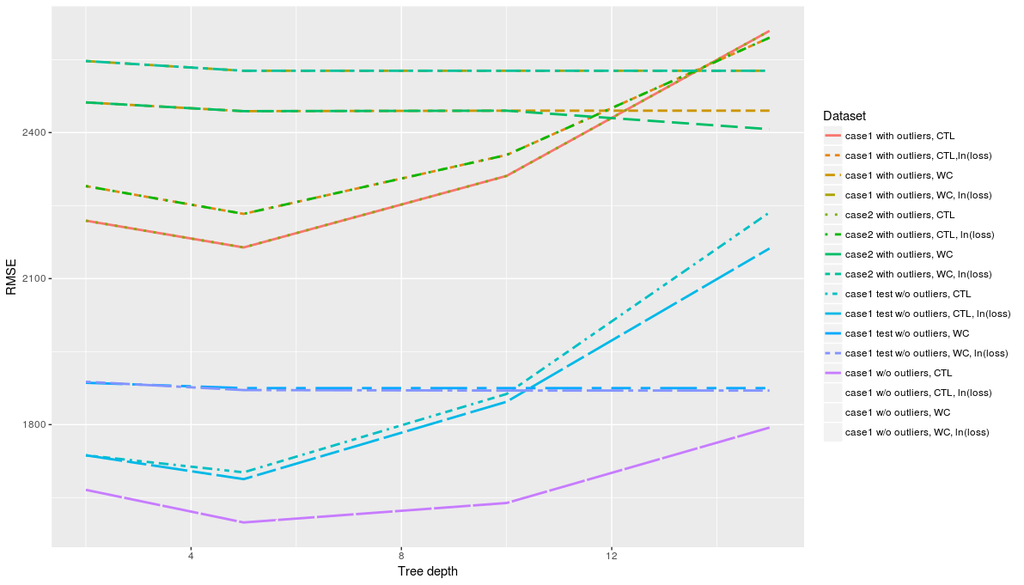

### Poprawa predykcji

Próba wykorzystania algorytmów 'lasso' oraz 'ridge'

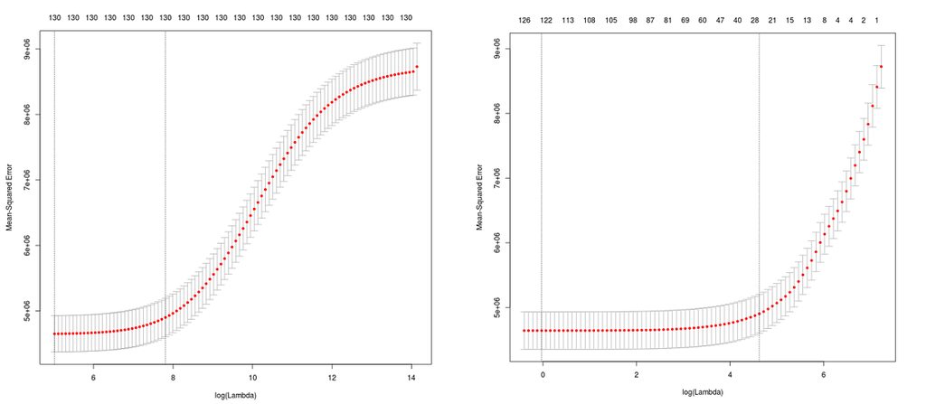

### Poprawa predykcji

Wyniki (Score = MAE):

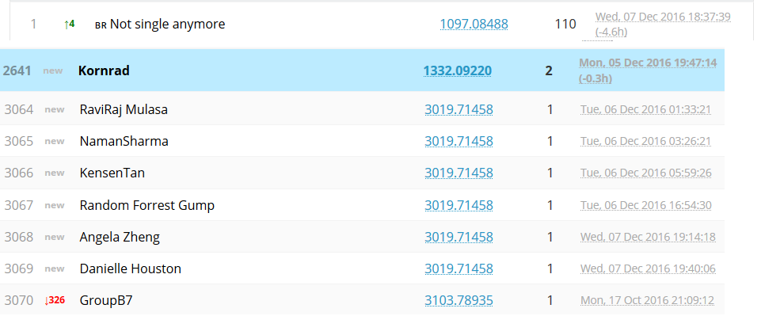

### Wnioski

- Najmniejszym pierwiastkiem średniego błędu kwadratowego (po usunięciu wartości odstających) charakteryzował się model XGB o maksymalnej głębokości drzewa równej 5, trenowany na zbiorze 'case1' oraz zmiennych co najmniej słabo skorelowanych ze zmienną `loss`
- Wśród modeli liniowych najlepsze parametry osiągnął model trenowany na zbiorze 'case1' (po usunięciu wartości odstających) oraz zmiennych silnie skorelowanych ze zmienną `loss`
- Najlepsze spośród modeli XGB oraz GLM osiągały zbliżone wartości średniego błędu kwadratowego
- Metody lasso oraz ridge nie podniosły jakości modelu

### Problemy, które wystąpiły w czasie trwania projektu

- problemy konfiguracyjne związane z programami: Apache Hadoop oraz Apache Spark
- problemy z zaawansowaną manipulacją danymi w Apache Spark

### Zdobyta wiedza

- Podstawowe umiejętności z zakresu instalacji, konfiguracji oraz obsługi oprogramowania:
  - Apache Flume
  - Apache Hadoop
  - Apache Spark
  - sparklyr
- Poszerzenie wiedzy na temat regresji liniowej oraz wykorzystywanych metod optymalizacyjnych